# Point estimation

POLI 210 - Seminar 7

Brad LeVeck

October 14, 2026

## The question behind an estimate

- We observe one study, but could have observed different outcomes.
- How does the rule producing our estimate behave across repeated studies?
- Does it target the right quantity? Does more data help?

Today: **point estimates → sampling distributions → causal comparisons.**

Optional extension: estimated standard errors and the t distribution.

Reading: PSD 5.6; a return to the CLT and t distribution from last week.

## A motivating field experiment

Gerber, Green, and Larimer studied social-pressure mailings and turnout.

| Mailing | Observed turnout |
| --- | --- |
| Neighbors | 37.8% |
| Civic Duty | 31.5% |

The observed difference is about **6.3 percentage points**.

Is this the effect of the mailing, or could the groups differ for other reasons? **Random assignment is the key design feature.**

Example and rounded figures from Blackwell’s estimation slides, based on Gerber, Green, and Larimer (2008). Civic Duty is an alternative mailing, not the no-mail control.

## Estimand, estimator, estimate

| Object | Meaning | Example |
| --- | --- | --- |
| Estimand | Quantity we want | Average causal effect, $\tau$ |
| Estimator | Rule applied to random data | $\widehat\tau=\bar Y_1-\bar Y_0$ |
| Estimate | Realized numerical result | About 6.3 percentage points |

Before collecting data, the estimator is a **random variable**.

Its distribution depends on both the population and how we conduct the study.

## What is a causal effect?

For unit $i$, imagine two potential outcomes:

$$Y_i(1):\text{ outcome under treatment},\qquad
Y_i(0):\text{ outcome under control}.$$

The individual effect is $\tau_i=Y_i(1)-Y_i(0)$.

For a fixed population of $N$ units:

$$\tau=\frac1N\sum_{i=1}^N\bigl[Y_i(1)-Y_i(0)\bigr].$$

We observe only one potential outcome for each unit, not its individual effect.

## Assignment determines what we observe

If $D_i=1$ means treated, the observed outcome is

$$Y_i=D_iY_i(1)+(1-D_i)Y_i(0).$$

Our estimate compares **different people**:

$$\widehat\tau=\underbrace{\bar Y_1}_{\text{treated mean}}-
\underbrace{\bar Y_0}_{\text{control mean}}.$$

A simulation can reveal both potential outcomes. An actual experiment cannot.

Assume well-defined treatments, no spillovers, and observation of assigned outcomes.

## Two sources of randomness

| Random assignment | Random sampling |
| --- | --- |
| Who receives treatment? | Who enters the study? |
| Can change while the units stay fixed | Produces a new set of units |
| Justifies treatment/control comparability | Connects a sample to a population |

An experiment can use random assignment without a random population sample.

When describing a sampling distribution, ask: **What gets repeated?**

## From repeated studies to a distribution

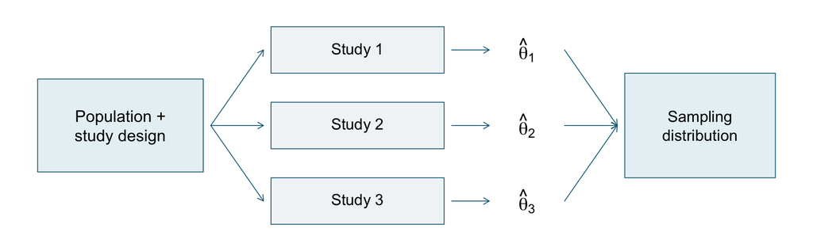

Each repetition produces **one estimate**, not one observation.

The sampling distribution is the distribution of that estimator.

## A simple model for repeated turnout studies

For illustration, suppose two independent samples of 200 voters have turnout probabilities 0.378 and 0.315.

```r
set.seed(210071)
B <- 10000
estimates <- rbinom(B, 200, .378) / 200 -
             rbinom(B, 200, .315) / 200
```

This model’s true difference is $0.063$.

These are **invented repeated studies**, not a reconstruction of the original experiment’s household assignment or standard errors.

## One estimator, many possible estimates

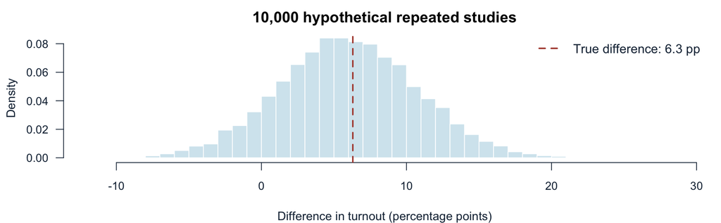

The spread measures uncertainty across studies; the center addresses bias.

## Unbiasedness: correct on average

$$\operatorname{Bias}(\widehat\theta)
=E[\widehat\theta]-\theta.$$

An estimator is **unbiased** if $E[\widehat\theta]=\theta$.

Under complete random assignment of a fixed number to each arm:

$$E_D[\bar Y_1]=\overline{Y(1)},\qquad E_D[\bar Y_0]=\overline{Y(0)},$$
$$E_D[\widehat\tau]=\overline{Y(1)}-\overline{Y(0)}=\tau.$$

The expectation averages over **assignments**, holding potential outcomes fixed.

## Unbiased does not mean exact

- Each particular assignment can produce imbalance.
- Some estimates are too high; others are too low.
- Unbiasedness describes their average, not a guarantee for your study.

**In simulation:** compare `mean(estimates)` with the known truth.

**In a small experiment:** enumerate every possible assignment for an exact expectation.

## Precision and standard error

The **standard error** is the SD of an estimator’s sampling distribution:

$$\operatorname{SE}(\widehat\theta)=\sqrt{\operatorname{Var}(\widehat\theta)}.$$

For two **independent IID samples**:

$$\operatorname{Var}(\bar Y_1-\bar Y_0)
=\frac{\sigma_1^2}{n_1}+\frac{\sigma_0^2}{n_0}.$$

This is the model on slide 9. In a fixed pool allocated without replacement, the arm means are not independent; the variance calculation is different.

## Mean squared error combines bias and spread

$$\operatorname{MSE}(\widehat\theta)
=E\bigl[(\widehat\theta-\theta)^2\bigr]
=\operatorname{Var}(\widehat\theta)+\operatorname{Bias}(\widehat\theta)^2.$$

- Variance: spread around the estimator’s own expectation.
- Squared bias: how far that expectation is from the target.

A very precise estimate can still be systematically wrong.

**In simulation:** `mean((estimates - truth)^2)`.

## Consistency: concentration as n grows

$\widehat\theta_n$ is **consistent** for $\theta$ if, for every $\epsilon>0$,

$$P\bigl(|\widehat\theta_n-\theta|>\epsilon\bigr)\longrightarrow0.$$

Equivalently, $\widehat\theta_n\xrightarrow{p}\theta$.

This is about a **sequence of larger studies**, not more repetitions of the same-sized study.

Unbiasedness asks about the center at a given $n$; consistency asks about concentration as $n$ grows.

## Centering and concentration are different

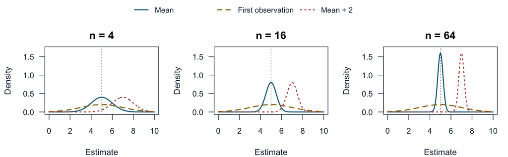

Here $X_i\overset{\mathrm{iid}}\sim N(5,2^2)$. Which estimator is unbiased? Which is consistent for 5?

## Unbiasedness is neither enough nor necessary

**Not enough:** $X_1$ estimates $\mu$ without bias, but ignores additional data. Its spread does not shrink.

**Not necessary:** for IID data with variance $\sigma^2$,

$$V_n=\frac1n\sum_{i=1}^n(X_i-\bar X)^2,\qquad
E[V_n]=\frac{n-1}{n}\sigma^2.$$

$V_n$ is biased downward at finite $n$, yet $V_n\xrightarrow{p}\sigma^2$.

Finite-sample bias can vanish as the sample grows.

## A useful route to consistency

Apply Markov’s inequality to $(\widehat\theta_n-\theta)^2$:

$$P(|\widehat\theta_n-\theta|\ge\epsilon)
\le\frac{E[(\widehat\theta_n-\theta)^2]}{\epsilon^2}
=\frac{\operatorname{MSE}(\widehat\theta_n)}{\epsilon^2}.$$

So **MSE going to zero is sufficient** for consistency.

For $\bar X_n$, bias is zero and variance is $\sigma^2/n$. This recovers our finite-variance proof of the weak LLN.

## More data must address the right problem

For independent samples, both group sizes must grow to drive

$$\frac{\sigma_1^2}{n_1}+\frac{\sigma_0^2}{n_0}\longrightarrow0.$$

But shrinking this variance does not remove a persistent difference between **the comparison we estimate** and **the causal effect we want**.

We’ll return to this distinction with self-selection after the break.

## Break

When we return:

1. Why large observational studies can miss a causal effect.
2. Work through potential outcomes and the B3 simulation workflow.
3. If time permits: estimated standard errors and the t distribution.

## Return to the causal question

In an observational study, people may choose treatment.

The comparison we observe is

$$E[Y\mid D=1]-E[Y\mid D=0]
=E[Y(1)\mid D=1]-E[Y(0)\mid D=0].$$

But the population ATE is $E[Y(1)-Y(0)]$.

Why might these differ even with a huge sample?

## Add and subtract the missing comparison

Add and subtract $E[Y(0)\mid D=1]$:

$$\begin{aligned}
E[Y\mid D=1]-E[Y\mid D=0]
&=E[Y(1)\mid D=1]-E[Y(0)\mid D=1]\\
&\quad+E[Y(0)\mid D=1]-E[Y(0)\mid D=0]\\
&=\mathrm{ATT}+\text{baseline selection}.
\end{aligned}$$

ATT is the average treatment effect among the treated.

The treated and control groups may differ **even without treatment**.

## ATT is not automatically ATE

$$\text{Observed population comparison}-\mathrm{ATE}
=(\mathrm{ATT}-\mathrm{ATE})+\text{baseline selection}.$$

- **ATT:** average effect for those who choose treatment.
- **ATE:** average effect for the entire target population.
- People may select on baseline outcomes, treatment effects, or both.

Population-level random assignment makes treatment independent of potential outcomes. In a finite experiment, the corresponding equalities hold **in expectation over assignments**, not for every realized allocation.

## Build the observed outcomes in R

A different four-unit toy example for the live demonstration:

```r
y0 <- c(10, 20, 15, 25)
y1 <- c(15, 22, 21, 25)
D <- as.integer((1:4) %in% c(1, 3))
y <- ifelse(D == 1, y1, y0)
mean(y[D == 1]) - mean(y[D == 0])
```

`%in%` identifies treated units; `ifelse()` chooses which outcome we observe. Square brackets select a group. Only `y` and `D` enter the estimator.

## Two B3 thought experiments

| First: fixed seven villages | Later: larger studies |
| --- | --- |
| Keep potential outcomes fixed | Draw new villages from seven types |
| Vary which two are treated | Compare random assignment and self-selection |
| Enumerate $\binom72=21$ assignments | Simulate studies at several $n$ |
| Study unbiasedness exactly | Explore concentration and limiting targets |

**n:** villages per study. **B:** simulated repetitions.

Increasing B sharpens the simulation; it does not fix the study design.

## Summarize estimates, not raw outcomes

For `estimates`, a vector of B repeated estimates:

```r
mean(estimates) - truth                # simulated bias
sd(estimates)                         # sampling SD
mean((estimates - truth)^2)            # MSE
mean(abs(estimates - truth) <= 1)      # within 1 point
```

`sd(estimates)` estimates the estimator’s standard error.

Dividing by $\sqrt B$ instead estimates the Monte Carlo uncertainty in the **average simulated estimate**. It is a different quantity.

## Read concentration from a CDF

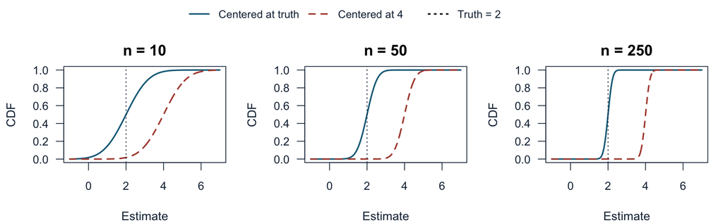

A narrow range containing most estimates creates a **steep CDF transition**. Where is the transition? Steeper does not necessarily mean more accurate.

## Takeaways and B3

- Unbiasedness concerns an expectation; consistency concerns concentration.
- Random assignment supports causal comparisons; sample size alone does not.
- Increasing n and increasing B answer different questions.

**B3:** one hypothetical village example, supplied simulation helpers, and short explanations. Use MSE and CDFs to distinguish precision from accuracy.

**Retrieval question:** Can an estimator become increasingly precise while remaining inconsistent for the ATE? Explain without using a formula.

## Optional extension: estimated SEs and t

How does estimating $\sigma$ change the distribution of a standardized mean?

An extension to revisit when we study statistical inference.

## SD of observations versus SE of a mean

For IID observations:

$$\operatorname{SD}(X_i)=\sigma,\qquad
\operatorname{SE}(\bar X)=\frac{\sigma}{\sqrt n}.$$

Usually $\sigma$ is unknown. Estimate it with the sample SD:

$$S^2=\frac1{n-1}\sum_{i=1}^n(X_i-\bar X)^2,\qquad
\widehat{\operatorname{SE}}(\bar X)=\frac S{\sqrt n}.$$

R: `sd(x)` estimates the spread of observations; `sd(x) / sqrt(length(x))` estimates the SE of their mean.

## Why divide by n − 1?

Estimating the center from the data makes squared deviations smaller:

$$\sum_i(X_i-\bar X)^2
=\sum_i(X_i-\mu)^2-n(\bar X-\mu)^2.$$

Taking expectations for IID data with finite variance:

$$E\!\left[\sum_i(X_i-\bar X)^2\right]
=n\sigma^2-n\frac{\sigma^2}{n}=(n-1)\sigma^2.$$

Thus $E[S^2]=\sigma^2$. The sample variance is unbiased. This does **not** imply $E[S]=\sigma$.

## Why does the estimated SD settle down?

Write the sample variance in terms of two averages:

$$S^2=\frac n{n-1}\left(\frac1n\sum_i X_i^2-\bar X^2\right).$$

For IID data with finite second moment, the LLN gives

$$S^2\xrightarrow{p}E[X^2]-\mu^2=\sigma^2.$$

If $\sigma>0$, then $S\xrightarrow{p}\sigma$. **Consistency**, rather than unbiasedness, is what we need next.

## Studentizing the sample mean

$$T_n=\frac{\bar X-\mu}{S/\sqrt n}
=\underbrace{\frac{\bar X-\mu}{\sigma/\sqrt n}}_{\xrightarrow{d}N(0,1)}
\underbrace{\frac{\sigma}{S}}_{\xrightarrow{p}1}
\xrightarrow{d}N(0,1).$$

This is an application of **Slutsky’s theorem**.

We need IID observations with $0<\sigma^2<\infty$. The estimated SE becomes correct **relative to** the true SE:

$$\frac{S/\sqrt n}{\sigma/\sqrt n}=\frac S\sigma\xrightarrow{p}1.$$

## A finite-sample answer under Normal sampling

If $X_i\overset{\mathrm{iid}}\sim N(\mu,\sigma^2)$, then

$$Z=\frac{\bar X-\mu}{\sigma/\sqrt n}\sim N(0,1),\qquad
U=\frac{(n-1)S^2}{\sigma^2}\sim\chi^2_{n-1},$$

and $Z$ and $U$ are independent. Therefore

$$T_n=\frac{Z}{\sqrt{U/(n-1)}}\sim t_{n-1}\quad\textbf{exactly}.$$

The random denominator reflects **estimating the variance**, not an arbitrary way to add spread. Small estimated SDs can produce large ratios.

## Exact t: compare the CDFs

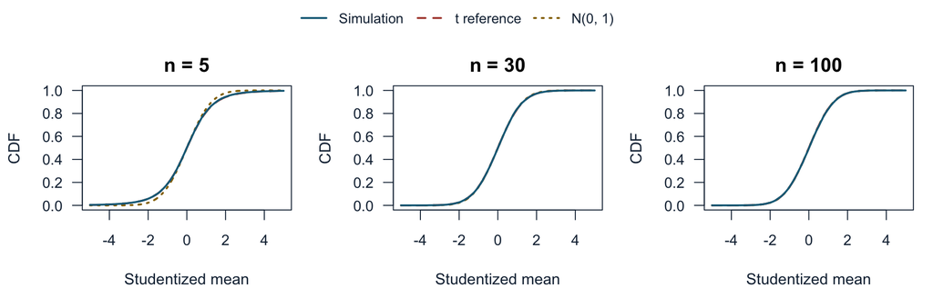

Normal observations: $\mu=5$, $\sigma=5$; 20,000 repetitions per $n$. Simulation estimates the CDF; the t result itself is exact.

## Make a small tail difference visible

For Normal observations, compare $P(T_n<-2)$ and $P(T_n>2)$.

| n | Left (sim.) | Right (sim.) | Each t tail | Each Normal tail |
| --- | --- | --- | --- | --- |
| 5 | 0.058 | 0.056 | 0.058 | 0.023 |
| 30 | 0.026 | 0.027 | 0.027 | 0.023 |
| 100 | 0.023 | 0.024 | 0.024 | 0.023 |

At $n=5$, $t_4$ has variance $4/(4-2)=2$, not 1. The t variance is $\nu/(\nu-2)$ when $\nu>2$.

These are **event probabilities**, not hypothesis tests yet.

## Change the population, keep its moments

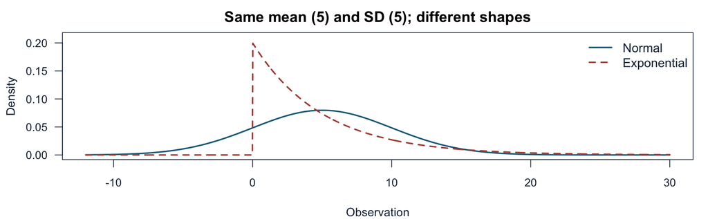

Same $\mu$ and $\sigma$ does not mean the same small-sample behavior. Use `rexp(n, rate = 1/5)` instead of `rnorm(n, 5, 5)`.

## Studentized does not automatically mean t

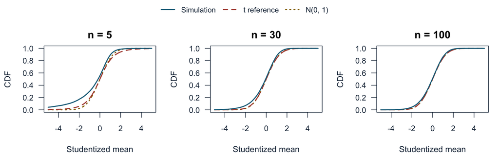

Exponential observations: the small-sample distribution is **not exactly t**. The estimated denominator and numerator can move together asymmetrically.

## Check both tails, not just total spread

| n | Left (sim.) | Right (sim.) | Each t tail | Each Normal tail |
| --- | --- | --- | --- | --- |
| 5 | 0.172 | 0.014 | 0.058 | 0.023 |
| 30 | 0.071 | 0.008 | 0.027 | 0.023 |
| 100 | 0.045 | 0.013 | 0.024 | 0.023 |

- A symmetric t curve cannot reproduce this finite-sample asymmetry.
- Increasing $n$ improves the Normal approximation here, but not instantly.
- There is no universal sample-size cutoff guaranteeing a good approximation.

## The lesson we will reuse for inference

| Claim | What supports it? |
| --- | --- |
| $T_n\sim t_{n-1}$ exactly | IID Normal observations |
| $T_n\xrightarrow{d}N(0,1)$ | IID, finite positive variance |
| A reference curve works at a particular $n$ | Assumptions and approximation quality |

In the live demo, compare `ecdf(t_values)` with `pt()` and `pnorm()`.

Confidence intervals and tests will use these ideas later.

## Reading and references

- Speegle and Clair, *Probability, Statistics, and Data*, [Section 5.6](https://probstatsdata.com/SimulationRV.html#pointestimators); revisit the t distribution in Section 5.5.
- Matthew Blackwell, [Estimation and Inference slides](https://www.mattblackwell.org/files/teaching/gov2000/s05-estimation-inference-slides-print.pdf), Sections 1-2. Instructional structure and turnout example adapted with permission.
- Gerber, Green, and Larimer (2008), “Social Pressure and Voter Turnout,” *American Political Science Review* 102(1): 33-48.
- Gerber and Green (2012), *Field Experiments*, Chapter 2, especially Table 2.1 and Section 2.6. Potential outcomes and selection-bias decomposition.
- R documentation: [`TDist`](https://stat.ethz.ch/R-manual/R-devel/library/stats/html/TDist.html).

Figures and simulation code were created for this seminar. The village and four-unit examples are hypothetical, not empirical effect estimates.